# Cardio Good Fitness Case Study

# Background:

Cardio Good Fitness, a Manufacturer of high-quality exercise equipments is seeking to improve the sales of one of their many products(treadmills). Cardio Good has requested a distinct customer profile be built for potential marketing towards, if one exists. Cardio Good hopes to target advertising directly to the developed customer profile. The dataset collected is on individuals who purchased a treadmill at a CardioGoodFitness retail store. The data are stored in the CardioGoodFitness.csv file.

# Objective:

- To identify the profile of a typical customer for each treadmill product offered by Cardio Good Fitness.
- Generate a set of insights and recommendations that will help Cardio Good Fitness in targeting new customers

# Data Description:

- Product: the model no. of the treadmill
- Age: in no of years, of the customer
- Gender: of the customer
- Education: in number of years, of the customer
- Marital Status: of the customer
- Usage: Average number of times the customer wants to use the treadmill every week
- Fitness: Self rated fitness score of the customer (5 - very fit, 1 - very unfit)
- Income: of the customer
- Miles: expected to run

```python
# import modules
import pandas as pd
import numpy as np
import matplotlib.pyplot as plt
import seaborn as sns

import warnings # to remove/supress output warnings
warnings.filterwarnings ("ignore")

%matplotlib inline
sns.set(color_codes=True) # adding a nice background

import os
```

```python
# get current working directory
os.getcwd()
```

```
'/Users/chydynma/University Of Texas'
```

```python
# Load dataset
Data = pd.read_csv('/Users/chydynma/downloads/CardioGoodFitness.csv')
Data.head() # view the first five rows of the dataset
```

|  | Product | Age | Gender | Education | MaritalStatus | Usage | Fitness | Income | Miles |
| --- | --- | --- | --- | --- | --- | --- | --- | --- | --- |
| 0 | TM195 | 18 | Male | 14 | Single | 3 | 4 | 29562 | 112 |
| 1 | TM195 | 19 | Male | 15 | Single | 2 | 3 | 31836 | 75 |
| 2 | TM195 | 19 | Female | 14 | Partnered | 4 | 3 | 30699 | 66 |
| 3 | TM195 | 19 | Male | 12 | Single | 3 | 3 | 32973 | 85 |
| 4 | TM195 | 20 | Male | 13 | Partnered | 4 | 2 | 35247 | 47 |

# DATA PREPARATION

```python
# Total number of unique observation in each column
Data.nunique()
```

```
Product           3
Age              32
Gender            2
Education         8
MaritalStatus     2
Usage             6
Fitness           5
Income           62
Miles            37
dtype: int64
```

- There are 3 categories of products and 2 categories each in 'Gender' and 'MaritalStatus' columns

```python
# view to size of dataset
Data.shape
```

```
(180, 9)
```

- The dataset has 180 rows and 9 columns

```python
# checking for the info to know the data type
Data.info()
```

```
<class 'pandas.core.frame.DataFrame'>
RangeIndex: 180 entries, 0 to 179
Data columns (total 9 columns):
 #   Column         Non-Null Count  Dtype
---  ------         --------------  -----
 0   Product        180 non-null    object
 1   Age            180 non-null    int64
 2   Gender         180 non-null    object
 3   Education      180 non-null    int64
 4   MaritalStatus  180 non-null    object
 5   Usage          180 non-null    int64
 6   Fitness        180 non-null    int64
 7   Income         180 non-null    int64
 8   Miles          180 non-null    int64
dtypes: int64(6), object(3)
memory usage: 12.8+ KB
```

- Product,Gender and Martial status are object datatype. They will be changed to categorical variables.
- While Age, Education,Usage,Fitness,Income,Miles are integer datatype.

# DATA PREPROCESSING

**Fixing the datatypes**

```python
# categorical column (object data type) would be converted to category data type

Data['Product'] = Data.Product.astype('category')
Data['Gender'] = Data.Gender.astype('category')
Data['MaritalStatus'] = Data.MaritalStatus.astype('category')
```

```python
Data.info()
```

```
<class 'pandas.core.frame.DataFrame'>
RangeIndex: 180 entries, 0 to 179
Data columns (total 9 columns):
 #   Column         Non-Null Count  Dtype
---  ------         --------------  -----
 0   Product        180 non-null    category
 1   Age            180 non-null    int64
 2   Gender         180 non-null    category
 3   Education      180 non-null    int64
 4   MaritalStatus  180 non-null    category
 5   Usage          180 non-null    int64
 6   Fitness        180 non-null    int64
 7   Income         180 non-null    int64
 8   Miles          180 non-null    int64
dtypes: category(3), int64(6)
memory usage: 9.5 KB
```

- There are 6 numeric columns and 3 categorical columns.

```python
# Checking for missing and duplicated values.

print(Data.isnull().sum())
print(Data.duplicated().sum())
```

```
Product          0
Age              0
Gender           0
Education        0
MaritalStatus    0
Usage            0
Fitness          0
Income           0
Miles            0
dtype: int64
0
```

- There are no missing and duplicated values.

```python
# Summary od numerical variables
Data.describe()
```

|  | Age | Education | Usage | Fitness | Income | Miles |
| --- | --- | --- | --- | --- | --- | --- |
| count | 180.000000 | 180.000000 | 180.000000 | 180.000000 | 180.000000 | 180.000000 |
| mean | 28.788889 | 15.572222 | 3.455556 | 3.311111 | 53719.577778 | 103.194444 |
| std | 6.943498 | 1.617055 | 1.084797 | 0.958869 | 16506.684226 | 51.863605 |
| min | 18.000000 | 12.000000 | 2.000000 | 1.000000 | 29562.000000 | 21.000000 |
| 25% | 24.000000 | 14.000000 | 3.000000 | 3.000000 | 44058.750000 | 66.000000 |
| 50% | 26.000000 | 16.000000 | 3.000000 | 3.000000 | 50596.500000 | 94.000000 |
| 75% | 33.000000 | 16.000000 | 4.000000 | 4.000000 | 58668.000000 | 114.750000 |
| max | 50.000000 | 21.000000 | 7.000000 | 5.000000 | 104581.000000 | 360.000000 |

**Observation**

```python
# summary for non-numerical variables
Data.describe(exclude='number')
```

|  | Product | Gender | MaritalStatus |
| --- | --- | --- | --- |
| count | 180 | 180 | 180 |
| unique | 3 | 2 | 2 |
| top | TM195 | Male | Partnered |
| freq | 80 | 104 | 107 |

- The most sold model is TM195
- There are more Male customers buying treadmills than Females
- Customers who are Partnered are buying more treadmills than Singles.

**Deep-dive into the 3 different product models TM195, TM498 and TM798**

```python
Data[Data['Product'] == 'TM195'].describe()
```

|  | Age | Education | Usage | Fitness | Income | Miles |
| --- | --- | --- | --- | --- | --- | --- |
| count | 80.000000 | 80.000000 | 80.000000 | 80.00000 | 80.00000 | 80.000000 |
| mean | 28.550000 | 15.037500 | 3.087500 | 2.96250 | 46418.02500 | 82.787500 |
| std | 7.221452 | 1.216383 | 0.782624 | 0.66454 | 9075.78319 | 28.874102 |
| min | 18.000000 | 12.000000 | 2.000000 | 1.00000 | 29562.00000 | 38.000000 |
| 25% | 23.000000 | 14.000000 | 3.000000 | 3.00000 | 38658.00000 | 66.000000 |
| 50% | 26.000000 | 16.000000 | 3.000000 | 3.00000 | 46617.00000 | 85.000000 |
| 75% | 33.000000 | 16.000000 | 4.000000 | 3.00000 | 53439.00000 | 94.000000 |
| max | 50.000000 | 18.000000 | 5.000000 | 5.00000 | 68220.00000 | 188.000000 |

**Observation**

- Number of TM195 sold is 80.
- Median and Mean Age of Customer who purchased TM195 is 26 and 28.5. This shows age is right skewed. This could mean we have outliers which can affect the model to be built if required.
- Mean number of years in Education is 15 and median is 16.
- Average usage is 3 times a week
- Expected miles to cover in a week is an Average 82.78 miles while median is 85.
- Self rated fitness is 3 that is average fitness level
- Mean and Median income is around 46,000

```python
Data[Data['Product'] == 'TM498'].describe()
```

|  | Age | Education | Usage | Fitness | Income | Miles |
| --- | --- | --- | --- | --- | --- | --- |
| count | 60.000000 | 60.000000 | 60.000000 | 60.00000 | 60.000000 | 60.000000 |
| mean | 28.900000 | 15.116667 | 3.066667 | 2.90000 | 48973.650000 | 87.933333 |
| std | 6.645248 | 1.222552 | 0.799717 | 0.62977 | 8653.989388 | 33.263135 |
| min | 19.000000 | 12.000000 | 2.000000 | 1.00000 | 31836.000000 | 21.000000 |
| 25% | 24.000000 | 14.000000 | 3.000000 | 3.00000 | 44911.500000 | 64.000000 |
| 50% | 26.000000 | 16.000000 | 3.000000 | 3.00000 | 49459.500000 | 85.000000 |
| 75% | 33.250000 | 16.000000 | 3.250000 | 3.00000 | 53439.000000 | 106.000000 |
| max | 48.000000 | 18.000000 | 5.000000 | 4.00000 | 67083.000000 | 212.000000 |

**Observations**

```python
Data[Data['Product'] == 'TM798'].describe()
```

|  | Age | Education | Usage | Fitness | Income | Miles |
| --- | --- | --- | --- | --- | --- | --- |
| count | 40.000000 | 40.000000 | 40.000000 | 40.000000 | 40.00000 | 40.000000 |
| mean | 29.100000 | 17.325000 | 4.775000 | 4.625000 | 75441.57500 | 166.900000 |
| std | 6.971738 | 1.639066 | 0.946993 | 0.667467 | 18505.83672 | 60.066544 |
| min | 22.000000 | 14.000000 | 3.000000 | 3.000000 | 48556.00000 | 80.000000 |
| 25% | 24.750000 | 16.000000 | 4.000000 | 4.000000 | 58204.75000 | 120.000000 |
| 50% | 27.000000 | 18.000000 | 5.000000 | 5.000000 | 76568.50000 | 160.000000 |
| 75% | 30.250000 | 18.000000 | 5.000000 | 5.000000 | 90886.00000 | 200.000000 |
| max | 48.000000 | 21.000000 | 7.000000 | 5.000000 | 104581.00000 | 360.000000 |

**Observations**

- Number of TM798 sold is 40.
- Mean and Median age of customers who purchases TM798 is 29 and 27 .
- Average and Median number of yaers in Education is 17 and 18.
- Expected Miles to cover in a week is on an Average 166 miles while median is 160.
- Average and Medina Income is 75K and 76K.

**Overall Observations from the deep dive**

- From the above statistical descriptions of the 3 products models, we can see customers with low age (19-21 years) bought TM195 and TM498. These group of customers can also be seen to be on the low income bracket (29K-47K).
- For TM798, We have high income earners. Although the quantity sold here is less compared to the other 3 models. This can confirm the inference that TM798 is the most expensive model.

# EXPLORATORY DATA ANALYSIS (EDA)

# Univariate Analysis

```python
def dist_box_violin(data):
 # function plots a combined graph for univariate analysis of continous variable
 #to check spread, central tendency , dispersion and outliers
    Name=data.name.upper()
    fig, axes =plt.subplots(1,3,figsize=(17, 7))
    fig.suptitle("SPREAD OF DATA FOR "+ Name  , fontsize=18, fontweight='bold')
    sns.distplot(data,kde=False,color='Blue',ax=axes[0])
    axes[0].axvline(data.mean(), color='y', linestyle='--',linewidth=2)
    axes[0].axvline(data.median(), color='r', linestyle='dashed', linewidth=2)
    axes[0].axvline(data.mode()[0],color='g',linestyle='solid',linewidth=2)
    axes[0].legend({'Mean':data.mean(),'Median':data.median(),'Mode':data.mode()})
    sns.boxplot(x=data,showmeans=True, orient='h',color="purple",ax=axes[1])
    #just exploring violin plot
    sns.violinplot(data,ax=axes[2],showmeans=True)
```

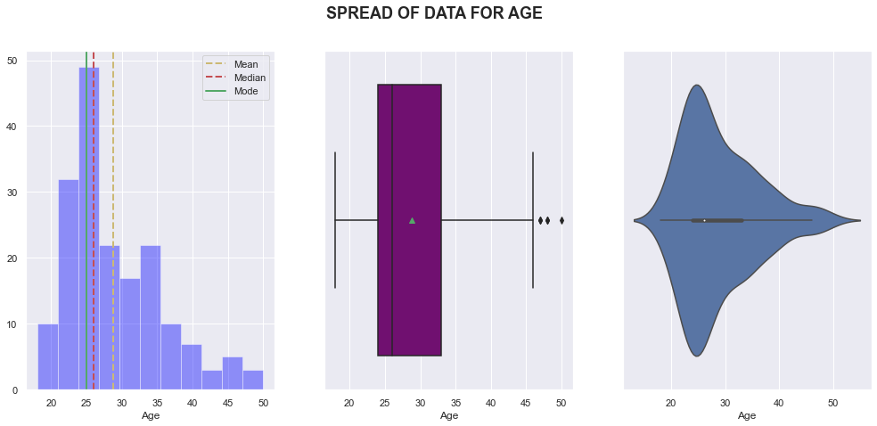

```python
dist_box_violin(Data.Age)
```

**Observation**

- Customers age appear to be skewed to right as mean is greater than median.
- Customers buying treadmil are less from 40years and above and customers less that 20years also buy less.
- We see the most purchase coming from younger customers.

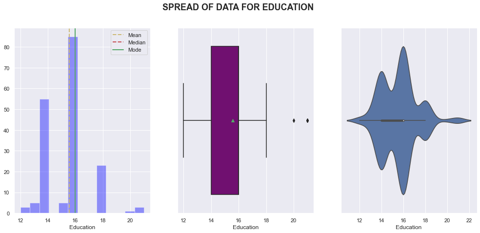

```python
dist_box_violin(Data.Education)
```

**Observations**

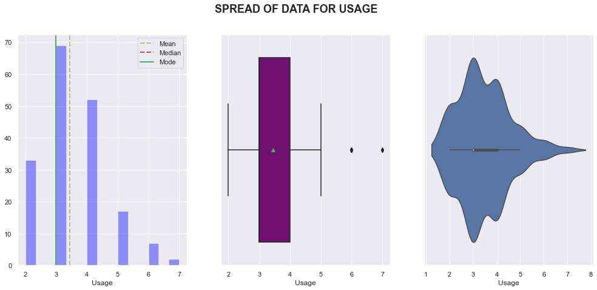

```python
dist_box_violin(Data.Usage)
```

**Observation**

- Usage of the products is mostly between 3-4 times a week
- There are outliers where usage is 6-7 times a week

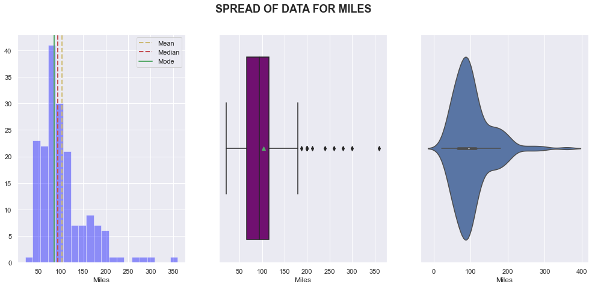

```python
dist_box_violin(Data.Miles)
```

**Observation**

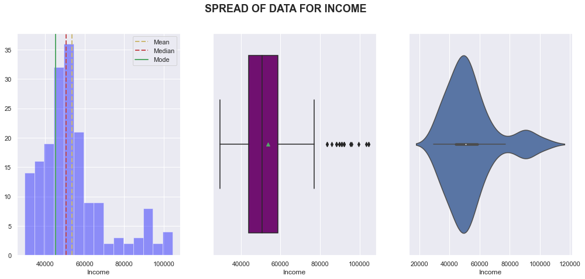

```python
dist_box_violin(Data.Income)
```

**Observation**

- Income is skewed towards right with an average of 55k.
- Income has some outliers. Only a few customers earn beyond 80K.

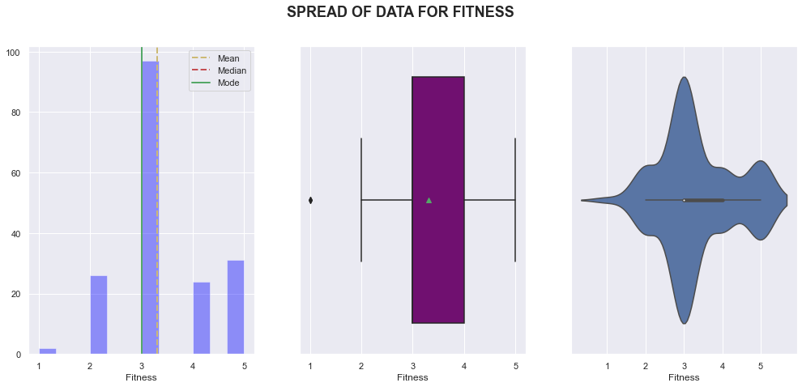

```python
dist_box_violin(Data.Fitness)
```

**Observation**

- Average fitness rating of customer is 3

# Let's explore the categorical variables now

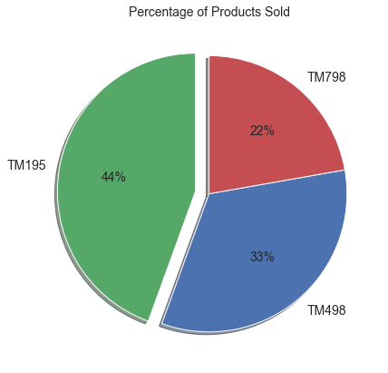

```python
# Plotting percentage of product sold using a pie chart


explosion = [0.1,0,0] # only "explode" the 1st slice
colors = ['g','b','r'] # set colors for each segment of the pie

plt.figure(figsize=(8,7))
plt.title('Percentage of Products Sold', fontsize=14) # set plot title
ProductCount = Data['Product'].value_counts()
plt.pie(ProductCount, labels = ProductCount.index, autopct = '%1.f%%', textprops={'fontsize': 14}, startangle=90,
        shadow=True, colors=colors, counterclock=True, explode=(explosion))

plt.show()
```

**Observation**

- TM195 has the height sale of 44%, followed by TM498 WITH 33% and the least sale was recorded at 22% for TM798.

```python
# Function to create barplots that indicate percentage for each category.
def bar_perc(plot, feature):
    '''
    plot
    feature: 1-d categorical feature array
    '''
    total = len(feature) # length of the column
    for p in ax.patches:
        percentage = '{:.1f}%'.format(100 * p.get_height()/total) # percentage of each class of the category
        x = p.get_x() + p.get_width() / 2 - 0.05 # width of the plot
        y = p.get_y() + p.get_height()           # hieght of the plot
        ax.annotate(percentage, (x, y), size = 12) # annotate the percantage
```

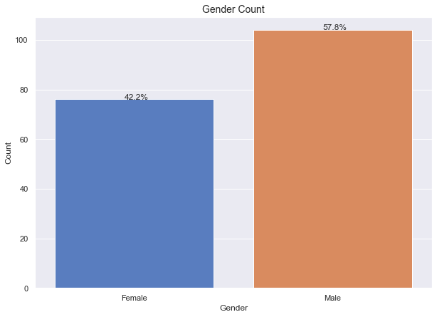

```python
# Plotting Gender count

plt.figure(figsize=(10,7))
sns.set_palette("muted")
ax = sns.countplot(Data['Gender'])
plt.xlabel('Gender')
plt.ylabel('Count')
bar_perc(ax,Data['Gender'])
ax.set_title("Gender Count", fontsize=14);
```

**Observation**

- There are more male customers than female. 57.8% male bought treadmills.

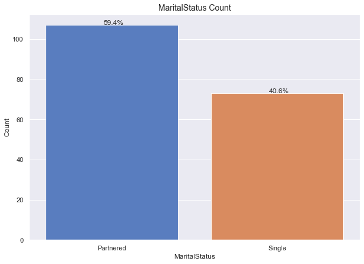

```python
plt.figure(figsize=(10,7))
sns.set_palette("muted")
ax = sns.countplot(Data['MaritalStatus'])
plt.xlabel('MaritalStatus')
plt.ylabel('Count')
bar_perc(ax,Data['MaritalStatus'])
ax.set_title("MaritalStatus Count", fontsize=14);
```

**Observation**

- 59.4% of customers are married (Partnered).

# Multivariate Analysis

**This is used to understand the interaction between different variables in a dataset.**

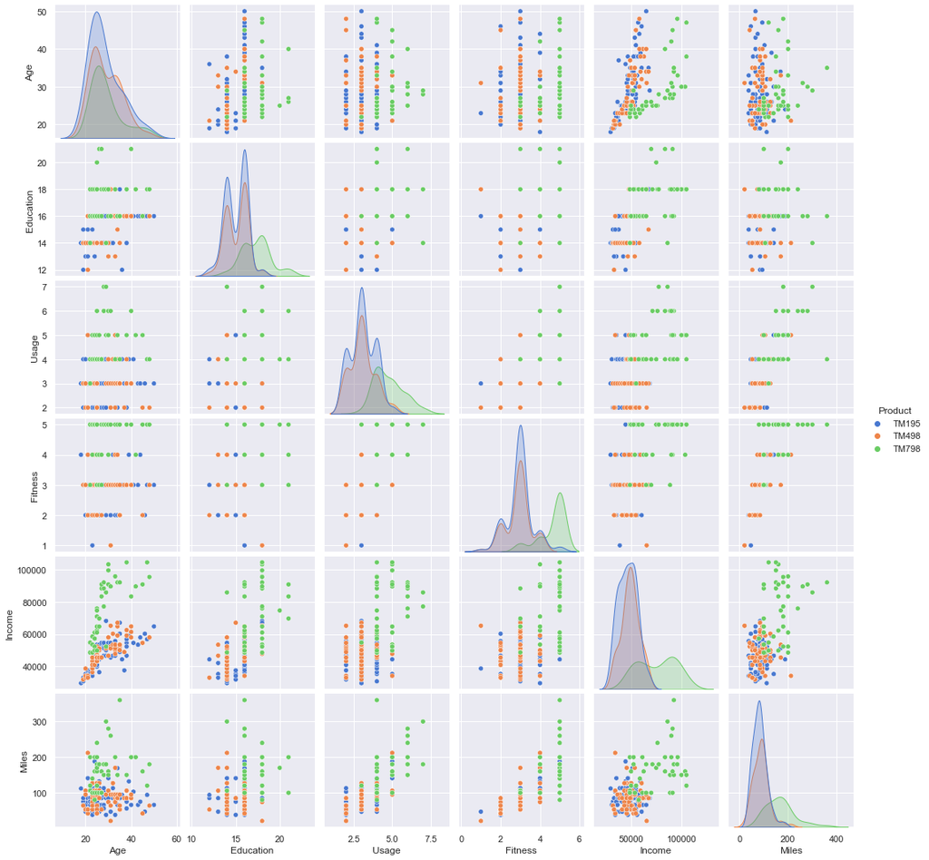

```python
# Let's have a quick overview of the dataset.
plt.figure(figsize=(10,7))
sns.pairplot(Data, hue='Product')
```

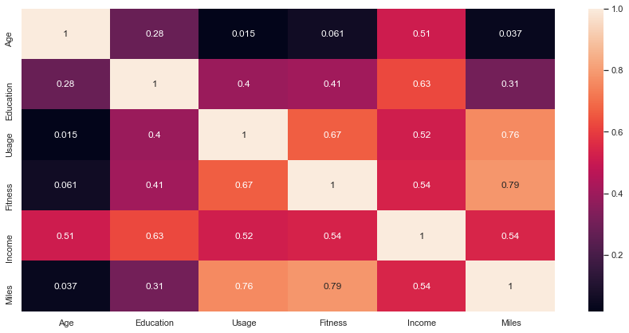

```python
plt.figure(figsize=(15,7))
sns.heatmap(Data.corr(), annot=True)
```

**Observation**

- From the above there is a correlation of 0.76 between Usage and Miles, 0.79 between Fitness and Miles. One can say customers who are more fit are expected to cover more miles and use products more times in a week, and those who are less fit are expected to have less usage.
- Also Usage and Fitness also has 0.67 correlation. Here, we can say there is some association with income and education, as customers with more education are expected to be have more income.

**Now let's bring look at variables that could affect the purchase of a product.**

**First, we would look at how between Income and Age affects Product purchase**

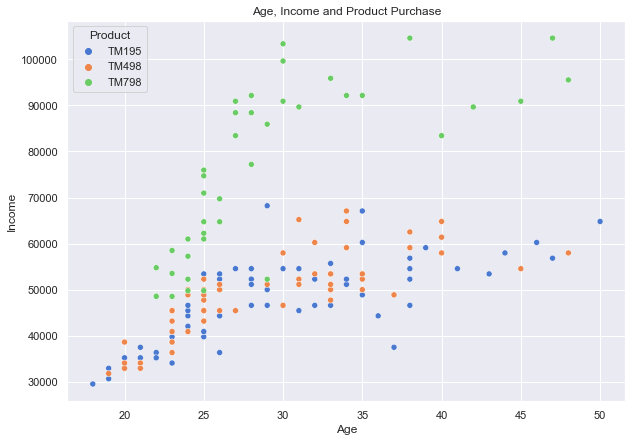

```python
# scatter plot age and income
plt.figure(figsize=(10,7))
ax = sns.scatterplot(y = 'Income', x = 'Age', data = Data, hue = 'Product')
ax.set_title("Age, Income and Product Purchase");
```

- We can see all ages with high income are purchasing TM798
- Customers less than 20years are buying all other models expect TM798. This could be as a result of low income earned by customers in the age range.
- From the above I can say, TM798 is an expensive model of treadmill.

# Let's consider some conditions that can guide us to identify different customer profiles.

**Product purchased vs Average Fitness**

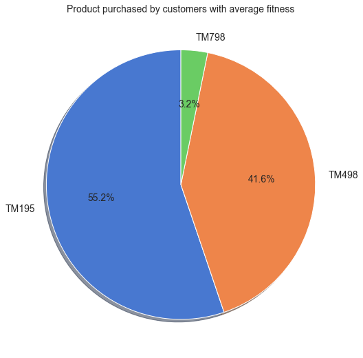

```python
plt.figure(figsize=(10,9))

fitness_count_less = Data[(Data['Fitness'] <= 3)].Product.value_counts() # 3 is criterial here as 3.3 is the overall average of fittness.(Data.describe())
plt.title("Product purchased by customers with average fitness", fontsize=14)
plt.pie(fitness_count_less, labels = fitness_count_less.index, textprops={'fontsize': 14}, startangle=90,
        counterclock=True, autopct = "%1.1f%%", shadow=True);
```

Customers who have fitness level less than or equal to 3 prefer to buy Products TM195 and TM498.

**Product purchased by customers expected to cover for less than 100 miles**

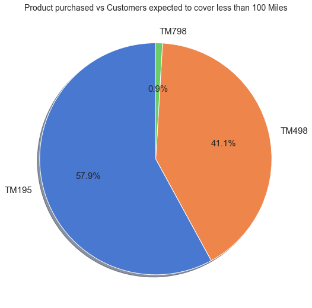

```python
plt.figure(figsize=(10,9))
MilesCount_less = Data[(Data['Miles'] <100)].Product.value_counts()
plt.title("Product purchased vs Customers expected to cover less than 100 Miles", fontsize=14)
plt.pie(MilesCount_less, labels = MilesCount_less.index, textprops={'fontsize': 15}, startangle=90,
        counterclock=True, autopct = "%1.1f%%", shadow=True);
```

Customer who have a target of less than 100miles purchase TM195 and TM498. We can say this could be one of the factors for TM195 having highest sale.

**Products purchased by Customers who earn an less income of 49,000**

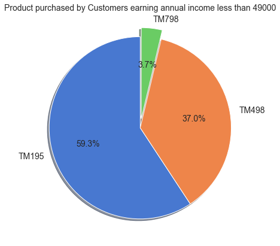

```python
plt.figure(figsize=(8,7))
explosion = [0,0,0.1] # only "explode" the 1st slice
less_Income_count = Data[(Data['Income'] < 49000)].Product.value_counts()
plt.title("Product purchased by Customers earning annual income less than 49000", fontsize=14)
plt.pie(less_Income_count, labels = less_Income_count.index, textprops={'fontsize': 14}, startangle=90,
        counterclock=True, autopct = "%1.1f%%", shadow=True, explode=(explosion));
```

- Customers who earn less than 49K are buying TM195 and TM498.
- This also shows more purchase is done TM195. It could be the cost of TM195 is less in price compared to other models.

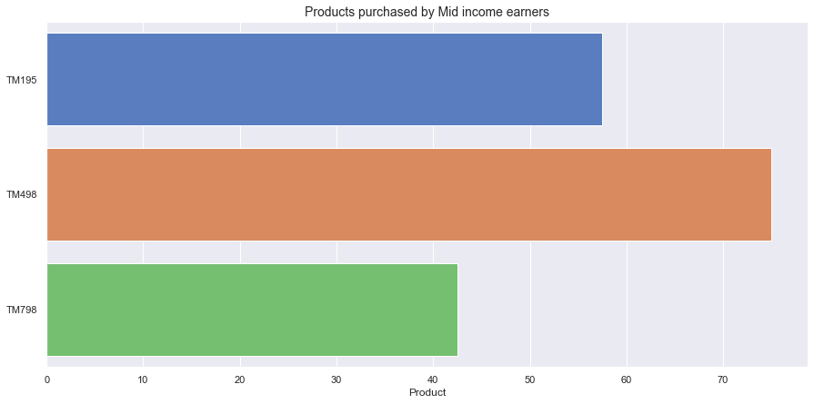

```python
plt.figure(figsize=(15,7))
mid_income_earners_perc = Data[(Data['Income'] < 70000) & ( Data['Income'] > 45000)].Product.value_counts()*100/Data.Product.value_counts()
plt.title('Products purchased by Mid income earners', fontsize=14)
sns.barplot(x = mid_income_earners_perc, y = mid_income_earners_perc.index);
```

**Product purchased based on distance covered.**

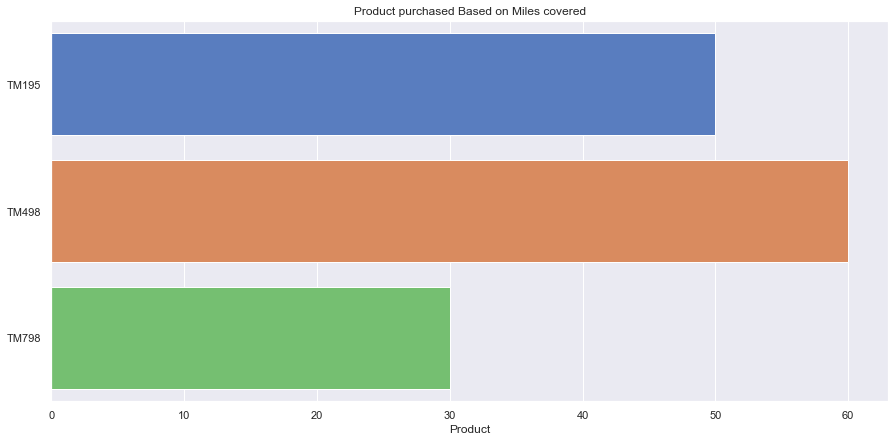

```python
# Average miles per week (80-150) will be the factor to determine distance covered
plt.figure(figsize=(15,7))
avg_workout_perc = Data[(Data['Miles'] < 150) & (Data['Miles'] > 80)].Product.value_counts()*100 / Data.Product.value_counts()
plt.title('Product purchased Based on Miles covered')
sns.barplot(x = avg_workout_perc, y = avg_workout_perc.index);
```

**Variables of females who bought TM798 (Income, usage, miles etc)**

```python
print("All female variable mean values")
print(Data[Data['Gender'] == 'Female'].mean())
print("Female who bought TM798 - variable mean values")
print(Data[(Data['Product'] == 'TM798') & (Data['Gender'] == 'Female')].mean())
```

```
All female variable mean values
Age             28.565789
Education       15.394737
Usage            3.184211
Fitness          3.026316
Income       49828.907895
Miles           90.013158
dtype: float64
Female who bought TM798 - variable mean values
Age             27.000000
Education       17.857143
Usage            5.000000
Fitness          4.571429
Income       73633.857143
Miles          180.000000
dtype: float64
```

Females who bought TM798 have higher income, expected to cover more miles and are more fit.